# Assignment 6: How the Internet Talks

Diana Negron and Kathleen Scopis

2022-11-29

# Introduction

The following code pulls in the most recent 900 tweets that use #septa and organizes them into a helpful wordcloud, as well as discusses emerging limitations in Twitter’s API.

# Methodology

Set working directory and install packages, set keys and tokens (found on Twitter’s Dev website) * CODE REDACTED *

## Pull Tweets from Twitter API

Current API rate limits appear to be capped at 900 tweets every 15 minutes

```r
#    Type 1 and hit Enter if 1 appears on the screen
twitteR::setup_twitter_oauth(ConsumerKey,ConsumerSecret,AccessToken,AccessSecret)

#    Set SSL certs globally
options(RCurlOptions = list(cainfo = system.file("CurlSSL", "cacert.pem", package = "RCurl")))


septa <- searchTwitter("septa", lang="en", n=900)


#     Saving twitter feed as a data frame
df <- do.call("rbind", lapply(septa, as.data.frame))
```

## Clean Tweets

Remove any extraneous or stop words that don’t relay any significance, numbers, and special characters What other words need to be removed?

```r
#     Corpora are collections of documents containing (natural language) text.
#     Used in packages which employ the infrastructure provided by package tm.
#     Each tweet is saved as a document
myCorpus <- Corpus(VectorSource(df$text));
myCorpus
```

```
## <<SimpleCorpus>>
## Metadata:  corpus specific: 1, document level (indexed): 0
## Content:  documents: 900
```

```r
#     Let's look at the first entry in the corpus
strwrap(myCorpus[[1]])
```

```
## [1] "@SEPTA_SOCIAL there needs to be better enforcement of smoking"
## [2] "restrictions on the subway. I just had to switch cars…"
## [3] "https://t.co/0YorhxBGwE"
```

```r
#     Let's do some additional cleaning
#     Defining toSpace function
#     Removing special characters
toSpace <- content_transformer(function(x, pattern) gsub(pattern, " ", x))
#Ignore the "transformation drops documents" warning messages.
myCorpus <- tm_map(myCorpus, toSpace, "@")
myCorpus <- tm_map(myCorpus, toSpace, "/")
myCorpus <- tm_map(myCorpus, toSpace, "]")
myCorpus <- tm_map(myCorpus, toSpace, "$")
#     Let's look at the first entry in the corpus
strwrap(myCorpus[[1]])
```

```
## [1] "SEPTA_SOCIAL there needs to be better enforcement of smoking"
## [2] "restrictions on the subway. I just had to switch cars… https: t.co"
## [3] "0YorhxBGwE"
```

```r
#     Removing numbers
myCorpus <- tm_map(myCorpus, removeNumbers)
#     Let's look at the first entry in the corpus
strwrap(myCorpus[[1]])
```

```
## [1] "SEPTA_SOCIAL there needs to be better enforcement of smoking"
## [2] "restrictions on the subway. I just had to switch cars… https: t.co"
## [3] "YorhxBGwE"
```

```r
#     Removing punctuation
myCorpus <- tm_map(myCorpus, removePunctuation)
#     Let's look at the first entry in the corpus
strwrap(myCorpus[[1]])
```

```
## [1] "SEPTASOCIAL there needs to be better enforcement of smoking"
## [2] "restrictions on the subway I just had to switch cars… https tco"
## [3] "YorhxBGwE"
```

```r
#     Removing non-ascii characters
myCorpus <- tm_map(myCorpus, function(x) iconv(x, "latin1", "ASCII", sub=""))
#     Let's look at the first entry in the corpus
strwrap(myCorpus[[1]])
```

```
## [1] "SEPTASOCIAL there needs to be better enforcement of smoking"
## [2] "restrictions on the subway I just had to switch cars https tco"
## [3] "YorhxBGwE"
```

```r
#     Removing English stop words
stopwords("english")
```

```
##   [1] "i"          "me"         "my"         "myself"     "we"
##   [6] "our"        "ours"       "ourselves"  "you"        "your"
##  [11] "yours"      "yourself"   "yourselves" "he"         "him"
##  [16] "his"        "himself"    "she"        "her"        "hers"
##  [21] "herself"    "it"         "its"        "itself"     "they"
##  [26] "them"       "their"      "theirs"     "themselves" "what"
##  [31] "which"      "who"        "whom"       "this"       "that"
##  [36] "these"      "those"      "am"         "is"         "are"
##  [41] "was"        "were"       "be"         "been"       "being"
##  [46] "have"       "has"        "had"        "having"     "do"
##  [51] "does"       "did"        "doing"      "would"      "should"
##  [56] "could"      "ought"      "i'm"        "you're"     "he's"
##  [61] "she's"      "it's"       "we're"      "they're"    "i've"
##  [66] "you've"     "we've"      "they've"    "i'd"        "you'd"
##  [71] "he'd"       "she'd"      "we'd"       "they'd"     "i'll"
```

[output cut: 20 more lines]

```r
myCorpus <- tm_map(myCorpus, removeWords, stopwords("english"))
#     Let's look at the first entry in the corpus
strwrap(myCorpus[[1]])
```

```
## [1] "SEPTASOCIAL needs better enforcement smoking restrictions subway I just"
## [2] "switch cars https tco YorhxBGwE"
```

```r
#     Removing our own stop words
myCorpus <- tm_map(myCorpus, removeWords,c( "may", "ttp", "qhb...", "https", "http...", "got", "get", "via", "much",  "many",  "ever", "did", "also", "let", "had", "wouldnt", "otherwise",  "seems", "seem" ))

#     Let's look at the first entry in the corpus
strwrap(myCorpus[[1]])
```

```
## [1] "SEPTASOCIAL needs better enforcement smoking restrictions subway I just"
## [2] "switch cars tco YorhxBGwE"
```

```r
#Removing whitespace characters
#When rendered, a whitespace character does not correspond to a visible
#mark, but typically does occupy an area on a page
myCorpus <- tm_map(myCorpus, stripWhitespace)
#     Let's look at the first entry in the corpus
strwrap(myCorpus[[1]])
```

```
## [1] "SEPTASOCIAL needs better enforcement smoking restrictions subway I just"
## [2] "switch cars tco YorhxBGwE"
```

```r
#Stemming (i.e., removing common word endings like "es", "ed", "ing" etc.)
#We might not want to do that -- Now, instead of having "Winteriscoming",
#we have "winteriscom"
 #     Let's look at the first entry in the corpus
strwrap(myCorpus[[1]])
```

```
## [1] "SEPTASOCIAL needs better enforcement smoking restrictions subway I just"
## [2] "switch cars tco YorhxBGwE"
```

```r
myCorpus
```

```
## <<SimpleCorpus>>
## Metadata:  corpus specific: 1, document level (indexed): 0
## Content:  documents: 900
```

# Results

## Text Matrix

```r
#Creating a Document Term Matrix (DTM)
#DTM is a mathematical matrix that describes the frequency of terms that occur in a collection of
#documents. In a DTM, rows correspond to documents (tweets) in thecollection and columns
#correspond to terms. Source: https://en.wikipedia.org/wiki/Document-term_matrix

#For example, see: http://d3j5m2z8950src.cloudfront.net/sites/default/files/TM16.jpg
dtm <- DocumentTermMatrix(myCorpus)
dtm
```

```
## <<DocumentTermMatrix (documents: 900, terms: 2131)>>
## Non-/sparse entries: 8699/1909201
## Sparsity           : 100%
## Maximal term length: 20
## Weighting          : term frequency (tf)
```

```r
dim(dtm)
```

```
## [1]  900 2131
```

```r
freq <- sort(colSums(as.matrix(dtm)), decreasing=TRUE)
freq
```

```
##                  tco                train            operating
##                  282                  271                  270
##                septa              minutes                  due
##                  235                  180                  171
##                going              service                 late
##                  163                  162                  157
##                 last               delays             operator
##                  155                  136                  135
##          septasocial                  rte       unavailability
##                  123                  121                  118
##                  bus              station                 will
##                   85                   84                   62
##                  the            thorndale           doylestown
##                   62                   62                   59
##              trenton             outbound                route
##                   46                   44                   42
##                 west               septas               trains
##                   40                   36                   34
##           norristown               issues                board
##                   33                   32                   31
##               thanks           warminster               street
##                   31                   30                   30
##              express                 next          septaphilly
##                   30                   29                   28
##                  mfl                  one                track
##                   28                   28                   28
##               newark          adamteterus                 rock
##                   26                   26                   25
##                 just           passengers                  amp
##                   24                   24                   24
##                 fern             canceled       transportation
##                   23                   23                   23
##                chase                  fox               center
##                   23                   23                   22
##                 this              changes                 hill
##                   22                   21                   21
##                 good                  can                 city
##                   21                   20                   20
##              waiting                 line             chestnut
##                   20                   20                   20
```

[output cut: 1367 more lines]

```
##                    1                    1                    1
##               clause                elves                 kick
##                    1                    1                    1
##                  mrs                 paws          septasafety
##                    1                    1                    1
##                 gift             nvfpsfyq               online
##                    1                    1                    1
##           promotions             combined             discount
##                    1                    1                    1
##                 gear             midnight                 hard
##                    1                    1                    1
##            tsycfrzfx                wrong                  str
##                    1                    1                    1
##             uyhbxgxv
##                    1
```

## Word Cloud

What does the following word cloud say about SEPTA? Are these sentiments overwhelmingly positive or negative?

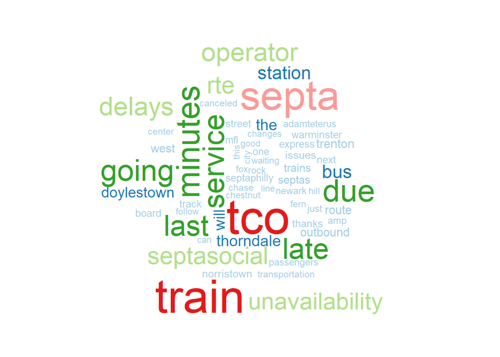

```r
wordcloud(names(freq), freq, min.freq=20, colors=brewer.pal(6, "Paired"))
```

# Limitations

## Twitter API Rate Limit

At the time of analysis, Twitter’s developer website has a stated rate limit of 900 tweets per 15 minutes per user.

## Spatial Distribution of Tweets

Alongside the sharp decline in number of tweets able to be extracted at one time, Twitter’s API has also recently updated the type of data available to downloaders.  
Latitude and longitude coordinate points are no longer available to view, therefore rendering the tweets impossible to map spatially.

The following code illustrates the process used to map the instances of tweets.

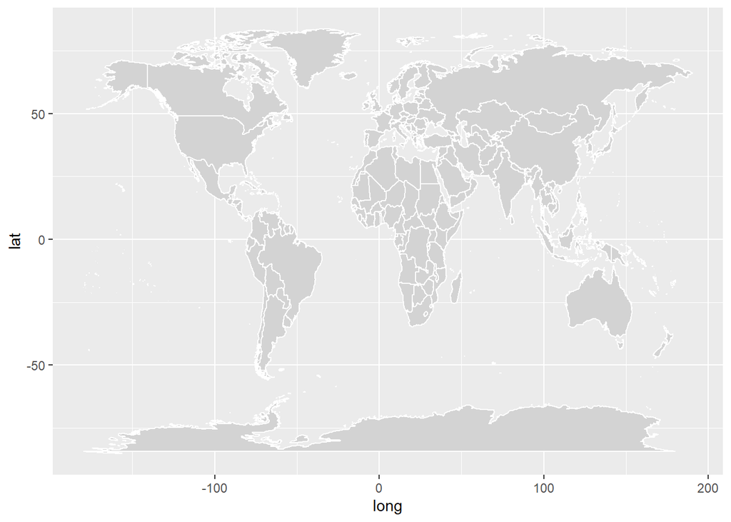

```r
#    Remove the columns replyToSID, replyToUID and replyToSN from data frame df
df$replyToSID <- NULL
df$replyToUID <- NULL
df$replyToSN <- NULL
head(df)
dim(df)

sum(is.na(df$longitude))


#    Let's look at the number of observations which have missing variable values
#    There are a few hundred observations left which have NON-missing values for
#    latitude and longitude.
df.geocoded=na.omit(df)
dim(df.geocoded)

#check average lat and long for tweet coordinates
mean(df.geocoded$latitude)
mean(df.geocoded$longitude)


write.csv(df.geocoded, file = "df_geocoded.csv")
geocoded.points <- read.csv("df_geocoded.csv")

write.csv(df, file = "septa.csv")

#Now let's plot the tweets on a world map!
world_map <- map_data("world")
ggplot(world_map, aes(x = long, y = lat, group = group)) +
  geom_polygon(fill="lightgray", colour = "white") +
  geom_point(data=geocoded.points, aes(x=longitude, y=latitude), inherit.aes=FALSE)
```